# Indicateur de Performance d’un Score : La Courbe ROC

Modélisation du Risque d’Impayé — Régression Logistique, Arbre de Décision, Forêt Aléatoire avec SMOTE

30 mars 2026

# 1 Introduction

L’objectif de ce projet est la **modélisation du risque d’impayé** pour les clients d’une société financière.

Dans le domaine du **risque de crédit**, il est crucial de détecter les clients susceptibles de ne pas rembourser leur crédit. Un modèle qui rate trop d’impayés (rappel faible) est bien plus dangereux qu’un modèle qui génère quelques fausses alarmes.

Nous allons :

1. Charger, nettoyer et explorer le jeu de données
2. Créer des variables financières pertinentes
3. Construire **3 modèles** : Régression Logistique, Arbre de Décision, Forêt Aléatoire
4. Appliquer **SMOTE** pour corriger le déséquilibre des classes
5. Évaluer et comparer tous les modèles avec la **courbe ROC** et l’**AUC**

# 2 Packages

```r
library(pROC)
library(rpart)
library(rpart.plot)
library(randomForest)
```

# 3 Chargement des Données

```
## Dimensions : 1134 lignes x 11 colonnes
```

```
##        Identifiant Montant Duree Telephone Taux_interet Ressources_Client
## 1  361           1   15000    48         0         7.26           3152.47
## 2  361           2    6000    60         1         8.82           1826.00
## 3  361           3    4000    60         1         8.52           2443.00
## 4  361           4   12000    60         1         8.82           2959.00
## 5  361           5    6000    12         1         3.42           6817.74
## 6  361           6    6000    24         1         7.32           2767.00
## 7  361           7    7000    24         1         8.22           1942.00
## 8  361           8   17000    48         0         7.26           1892.84
## 9  361           9   10000    48         1         8.52           1661.83
## 10 361          10    7000    60         1         8.52           2276.85
##    Charges_Client Nb_emprunteurs Assurance Client Payeur
## 1       1313.4600              1         1      0      0
## 2        379.0000              2         1      0      0
## 3        810.0000              2         0      1      0
## 4        578.0000              2         1      1      0
## 5       1660.0000              1         0      1      0
## 6        600.0000              2         0      1      0
## 7        814.7500              1         1      0      0
## 8       1041.6467              1         0      0      0
## 9        695.5833              2         1      0      0
## 10       726.0200              2         1      0      0
```

```r
summary(data)
```

```
##  Identifiant           Montant          Duree         Telephone
##  Length:1134        Min.   : 1500   Min.   :12.00   Min.   :0.0000
##  Class :character   1st Qu.: 5000   1st Qu.:36.00   1st Qu.:0.0000
##  Mode  :character   Median : 7000   Median :48.00   Median :1.0000
##                     Mean   : 7868   Mean   :45.22   Mean   :0.7302
##                     3rd Qu.:10000   3rd Qu.:60.00   3rd Qu.:1.0000
##                     Max.   :21500   Max.   :72.00   Max.   :1.0000
##   Taux_interet   Ressources_Client Charges_Client    Nb_emprunteurs
##  Min.   :3.420   Min.   :  300     Min.   :    1.0   Min.   :1.000
##  1st Qu.:8.220   1st Qu.: 1776     1st Qu.:  450.0   1st Qu.:1.000
##  Median :8.520   Median : 2469     Median :  681.8   Median :2.000
##  Mean   :8.233   Mean   : 2845     Mean   :  830.5   Mean   :1.539
##  3rd Qu.:8.520   3rd Qu.: 3290     3rd Qu.:  995.0   3rd Qu.:2.000
##  Max.   :9.480   Max.   :36752     Max.   :21364.8   Max.   :2.000
##    Assurance          Client           Payeur
##  Min.   :0.0000   Min.   :0.0000   Min.   :0.0000
##  1st Qu.:0.0000   1st Qu.:0.0000   1st Qu.:0.0000
##  Median :1.0000   Median :1.0000   Median :0.0000
##  Mean   :0.5353   Mean   :0.5952   Mean   :0.1332
##  3rd Qu.:1.0000   3rd Qu.:1.0000   3rd Qu.:0.0000
##  Max.   :1.0000   Max.   :1.0000   Max.   :1.0000
```

# 4 Nettoyage des Données

## 4.1 Nettoyage de l’identifiant

```r
data$Identifiant <- trimws(data$Identifiant)
```

## 4.2 Valeurs manquantes et doublons

```r
print(colSums(is.na(data)))
```

```
##       Identifiant           Montant             Duree         Telephone
##                 0                 0                 0                 0
##      Taux_interet Ressources_Client    Charges_Client    Nb_emprunteurs
##                 0                 0                 0                 0
##         Assurance            Client            Payeur
##                 0                 0                 0
```

```r
cat("\nDoublons :", sum(duplicated(data$Identifiant)), "\n")
```

```
##
## Doublons : 0
```

Aucune valeur manquante et aucun doublon — les données sont propres.

## 4.3 Conversion en facteurs

```r
data$Telephone      <- factor(data$Telephone,
                               levels = c(0,1), labels = c("Non", "Oui"))
data$Assurance      <- factor(data$Assurance,
                               levels = c(0,1), labels = c("Non", "Oui"))
data$Client         <- factor(data$Client,
                               levels = c(0,1), labels = c("Nouveau", "Ancien"))
data$Nb_emprunteurs <- factor(data$Nb_emprunteurs)
data$Payeur         <- factor(data$Payeur,
                               levels = c(0,1), labels = c("Impayé", "Payeur"))
str(data)
```

```
## 'data.frame':    1134 obs. of  11 variables:
##  $ Identifiant      : chr  "361           1" "361           2" "361           3" "361           4" ...
##  $ Montant          : int  15000 6000 4000 12000 6000 6000 7000 17000 10000 7000 ...
##  $ Duree            : int  48 60 60 60 12 24 24 48 48 60 ...
##  $ Telephone        : Factor w/ 2 levels "Non","Oui": 1 2 2 2 2 2 2 1 2 2 ...
##  $ Taux_interet     : num  7.26 8.82 8.52 8.82 3.42 7.32 8.22 7.26 8.52 8.52 ...
##  $ Ressources_Client: num  3152 1826 2443 2959 6818 ...
##  $ Charges_Client   : num  1313 379 810 578 1660 ...
##  $ Nb_emprunteurs   : Factor w/ 2 levels "1","2": 1 2 2 2 1 2 1 1 2 2 ...
##  $ Assurance        : Factor w/ 2 levels "Non","Oui": 2 2 1 2 1 1 2 1 2 2 ...
##  $ Client           : Factor w/ 2 levels "Nouveau","Ancien": 1 1 2 2 2 2 1 1 1 1 ...
##  $ Payeur           : Factor w/ 2 levels "Impayé","Payeur": 1 1 1 1 1 1 1 1 1 1 ...
```

## 4.4 Suppression de l’identifiant

```r
data <- data[, !names(data) %in% "Identifiant"]
cat("Dimensions finales :", nrow(data), "lignes x", ncol(data), "colonnes\n")
```

```
## Dimensions finales : 1134 lignes x 10 colonnes
```

## 4.5 Distribution de la variable cible

```r
freq <- table(data$Payeur)
pct  <- round(prop.table(freq) * 100, 1)
cat("Distribution :\n"); print(freq)
```

```
## Distribution :
```

```
##
## Impayé Payeur
##    983    151
```

```r
cat("\nProportion :\n"); print(pct)
```

```
##
## Proportion :
```

```
##
## Impayé Payeur
##   86.7   13.3
```

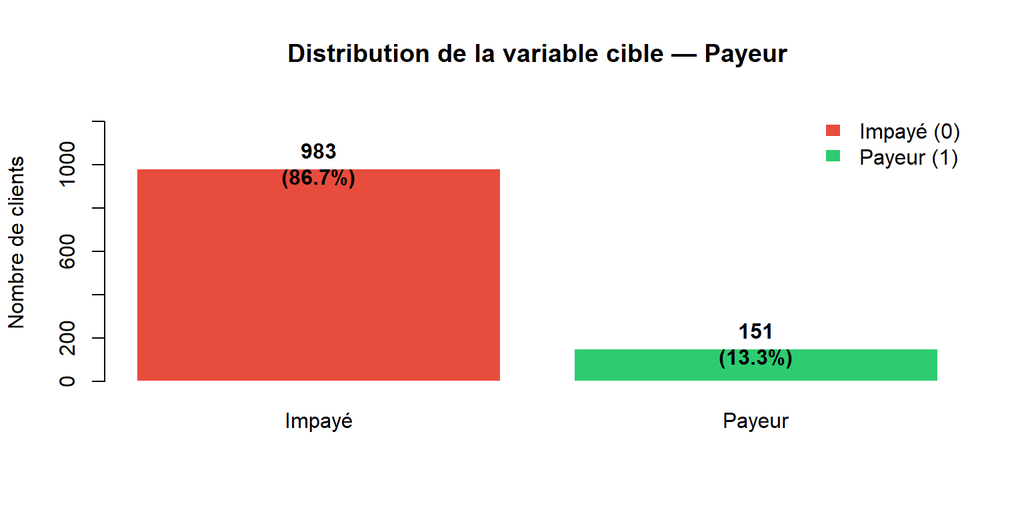

Le jeu de données est **fortement déséquilibré** : **86.7%** de clients Impayés contre **13.3%** de Payeurs. Sans correction, les modèles vont naturellement prédire “Impayé” pour tout le monde.

# 5 Analyse Exploratoire

## 5.1 Boxplots des variables numériques

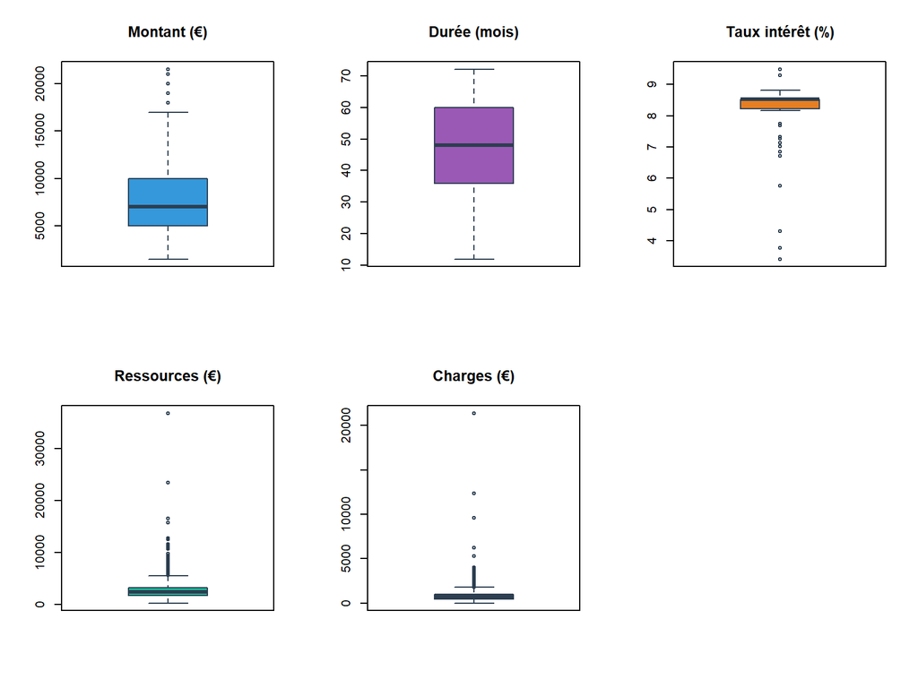

On observe des valeurs extrêmes sur les Ressources (max 36 752€) et les Charges (max 21 364€).

## 5.2 Variables catégorielles selon le statut

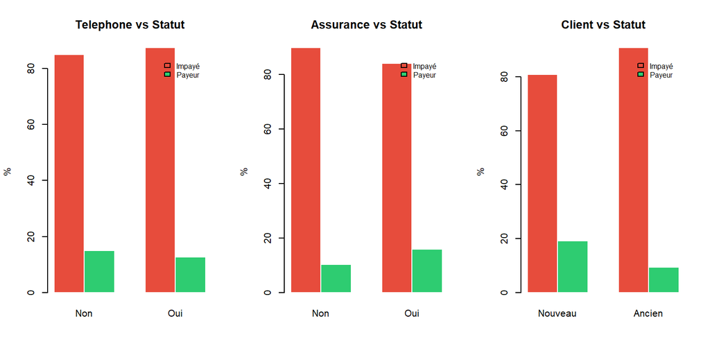

```r
par(mfrow = c(1, 3))
for (var in c("Telephone", "Assurance", "Client")) {
  t_var <- prop.table(table(data[[var]], data$Payeur), margin = 1) * 100
  barplot(t(t_var), beside = TRUE,
          col = c("#E74C3C", "#2ECC71"), border = "white",
          main = paste(var, "vs Statut"), ylab = "%",
          legend.text = c("Impayé", "Payeur"),
          args.legend = list(bty = "n", cex = 0.75))
}
```

```r
par(mfrow = c(1, 1))
```

## 5.3 Matrice de corrélation

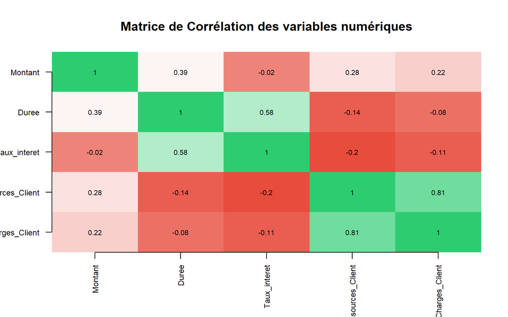

# 6 Variables Dérivées

```r
# Taux d'endettement
data$Taux_endettement <- round(data$Charges_Client / data$Ressources_Client * 100, 2)

# Mensualité estimée (formule des annuités)
data$Mensualite <- round(
  data$Montant * (data$Taux_interet / 100 / 12) /
  (1 - (1 + data$Taux_interet / 100 / 12)^(-data$Duree)), 2
)

# Reste à vivre
data$Reste_a_vivre <- round(
  data$Ressources_Client - data$Charges_Client - data$Mensualite, 2
)

head(data[, c("Taux_endettement", "Mensualite", "Reste_a_vivre")])
```

```
##   Taux_endettement Mensualite Reste_a_vivre
## 1            41.66     361.01       1478.00
## 2            20.76     124.03       1322.97
## 3            33.16      82.10       1550.90
## 4            19.53     248.05       2132.95
## 5            24.35     509.31       4648.43
## 6            21.68     269.51       1897.49
```

## 6.1 Variables dérivées selon le statut

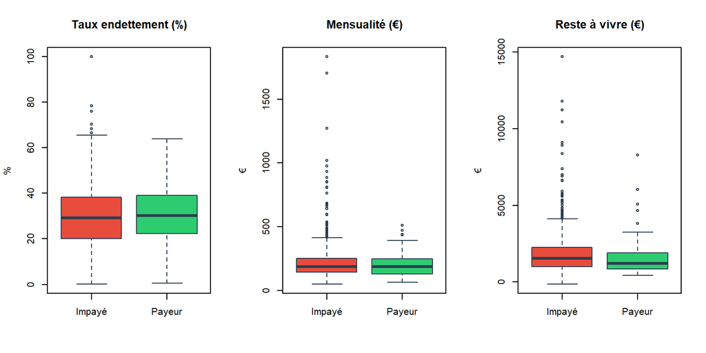

# 7 Séparation Train / Test (70% / 30%)

```r
set.seed(42)

n         <- nrow(data)
idx       <- sample(1:n, size = round(0.70 * n))
train_set <- data[idx, ]
test_set  <- data[-idx, ]

cat("Train :", nrow(train_set), "| Test :", nrow(test_set), "\n\n")
```

```
## Train : 794 | Test : 340
```

```r
cat("Proportions Train :\n")
```

```
## Proportions Train :
```

```r
print(round(prop.table(table(train_set$Payeur)) * 100, 1))
```

```
##
## Impayé Payeur
##   86.8   13.2
```

```r
cat("\nProportions Test :\n")
```

```
##
## Proportions Test :
```

```r
print(round(prop.table(table(test_set$Payeur)) * 100, 1))
```

```
##
## Impayé Payeur
##   86.5   13.5
```

Le déséquilibre est conservé dans les deux ensembles. Le **test restera intact** pour évaluer les modèles honnêtement.

# 8 Fonctions Utilitaires

```r
# Vraie étiquette sur le test
true_f     <- factor(ifelse(test_set$Payeur == "Impayé", "Impayé", "Payeur"),
                     levels = c("Payeur", "Impayé"))
true_label <- ifelse(test_set$Payeur == "Impayé", 1, 0)

# Calcul des métriques à partir d'une table de confusion
get_metrics <- function(cm, model_name) {
  acc  <- round(sum(diag(cm)) / sum(cm) * 100, 2)
  vp   <- cm["Impayé", "Impayé"]
  fp   <- cm["Impayé", "Payeur"]
  fn   <- cm["Payeur",  "Impayé"]
  prec <- round(vp / (vp + fp) * 100, 2)
  rec  <- round(vp / (vp + fn) * 100, 2)
  f1   <- round(2 * prec * rec / (prec + rec), 2)
  data.frame(Modèle = model_name, Accuracy = acc,
             Précision = prec, Rappel = rec, F1_Score = f1)
}

# Affichage d'une matrice de confusion
plot_cm <- function(cm, titre, couleur) {
  image(1:2, 1:2, t(matrix(as.numeric(cm), 2, 2)),
        col  = colorRampPalette(c("white", couleur))(10),
        xaxt = "n", yaxt = "n",
        xlab = "Prédit", ylab = "Réel", main = titre)
  axis(1, at = 1:2, labels = colnames(cm))
  axis(2, at = 1:2, labels = rownames(cm), las = 1)
  for (i in 1:2) for (j in 1:2)
    text(j, i, cm[i, j], cex = 2, font = 2,
         col = ifelse(cm[i, j] > 150, "white", "black"))
}
```

# 9 SMOTE — Rééquilibrage des Classes

## 9.1 Principe

SMOTE génère des observations synthétiques pour la **classe minoritaire** (ici les **Payeurs** = 13.3%) :

$$x_{new} = x + \lambda \cdot (x_{voisin}
- x), \quad \lambda \in [0,1]$$

On crée un nouveau client entre deux clients Payeurs réels, en ajoutant un bruit aléatoire sur chaque variable numérique.

## 9.2 Application

```
## Avant SMOTE :
```

```
##
## Impayé Payeur
##    689    105
```

```
##
## Après SMOTE :
```

```
##
## Impayé Payeur
##    689    525
```

```
##
## Proportions après SMOTE :
```

```
##
## Impayé Payeur
##   56.8   43.2
```

## 9.3 Visualisation avant vs après SMOTE

[figure not shown]

# 10 Modélisation

## 10.1 Modèle 1 — Régression Logistique

### 10.1.1 Sans SMOTE

```
##
## Call:
## glm(formula = Payeur ~ . - Mensualite, family = binomial(link = "logit"),
##     data = train_set)
##
## Coefficients:
##                     Estimate Std. Error z value Pr(>|z|)
## (Intercept)        0.5340938  2.3251694   0.230 0.818324
## Montant            0.0001286  0.0001035   1.243 0.214040
## Duree             -0.0003135  0.0188440  -0.017 0.986724
## TelephoneOui       0.2978834  0.2506132   1.189 0.234590
## Taux_interet      -0.2225284  0.2218414  -1.003 0.315814
## Ressources_Client -0.0044050  0.0040618  -1.084 0.278152
## Charges_Client     0.0039695  0.0041058   0.967 0.333645
## Nb_emprunteurs2   -0.4111709  0.2371800  -1.734 0.082992 .
## AssuranceOui       0.4440321  0.2266559   1.959 0.050106 .
## ClientAncien      -0.7489536  0.2232133  -3.355 0.000793 ***
## Taux_endettement   0.0008856  0.0166757   0.053 0.957645
## Reste_a_vivre      0.0042587  0.0040642   1.048 0.294709
## ---
## Signif. codes:  0 '***' 0.001 '**' 0.01 '*' 0.05 '.' 0.1 ' ' 1
##
## (Dispersion parameter for binomial family taken to be 1)
##
##     Null deviance: 620.31  on 793  degrees of freedom
## Residual deviance: 581.90  on 782  degrees of freedom
## AIC: 605.9
##
## Number of Fisher Scoring iterations: 6
```

### 10.1.2 Interprétation des coefficients

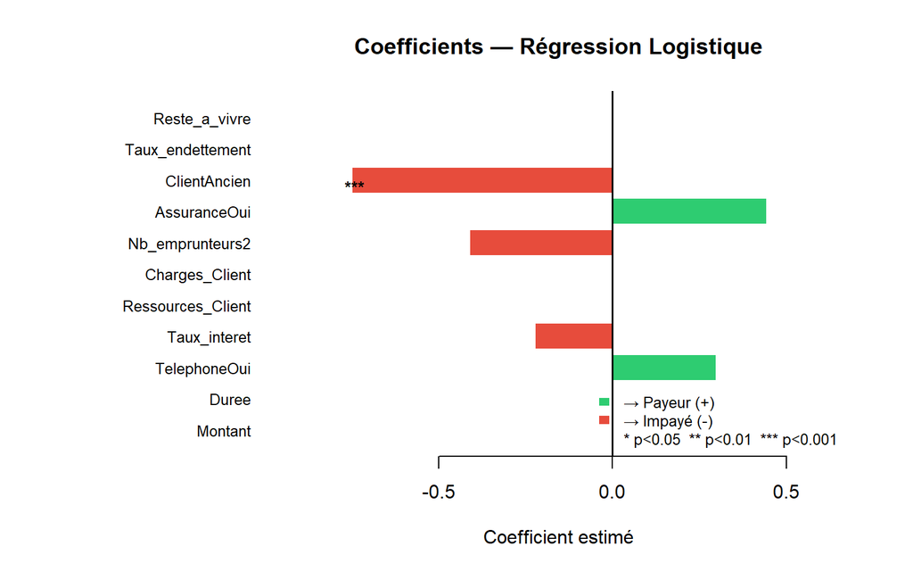

### 10.1.3 Prédictions — Sans SMOTE

```r
prob_lr   <- predict(modele_lr, test_set, type = "response")
pred_lr   <- factor(ifelse(prob_lr >= 0.5, "Payeur", "Impayé"),
                    levels = c("Payeur", "Impayé"))
cm_lr     <- table(Prédit = pred_lr, Réel = true_f)
print(cm_lr)
```

```
##         Réel
## Prédit  Payeur Impayé
##   Payeur      0      0
##   Impayé     46    294
```

```r
metr_lr   <- get_metrics(cm_lr, "LR — Sans SMOTE")
```

### 10.1.4 Avec SMOTE

```r
modele_lr_smote <- glm(Payeur ~ . - Mensualite, data = train_smote,
                       family = binomial(link = "logit"))
prob_lr_smote   <- predict(modele_lr_smote, test_set, type = "response")
pred_lr_smote   <- factor(ifelse(prob_lr_smote >= 0.5, "Payeur", "Impayé"),
                          levels = c("Payeur", "Impayé"))
cm_lr_smote     <- table(Prédit = pred_lr_smote, Réel = true_f)
print(cm_lr_smote)
```

```
##         Réel
## Prédit  Payeur Impayé
##   Payeur     18     62
##   Impayé     28    232
```

```r
metr_lr_smote   <- get_metrics(cm_lr_smote, "LR — Avec SMOTE")
```

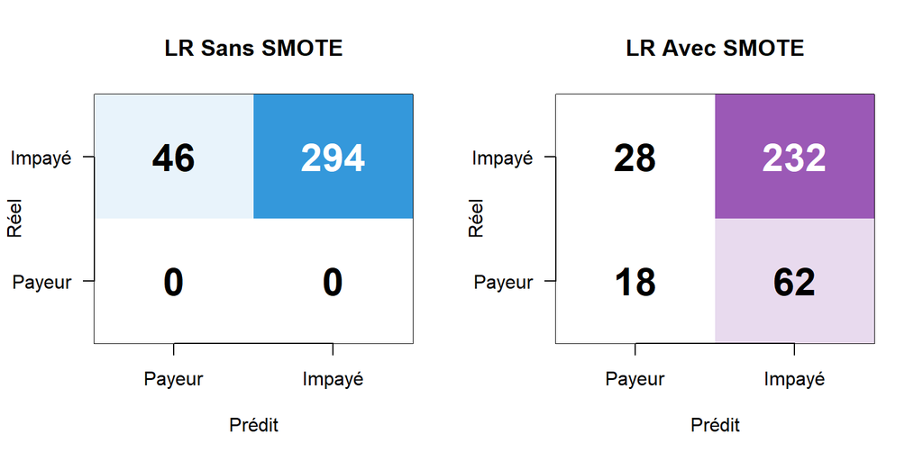

```r
par(mfrow = c(1, 2))
plot_cm(cm_lr,       "LR Sans SMOTE", "#3498DB")
plot_cm(cm_lr_smote, "LR Avec SMOTE", "#9B59B6")
```

```r
par(mfrow = c(1, 1))
```

## 10.2 Modèle 2 — Arbre de Décision

### 10.2.1 Sans SMOTE

```r
modele_arbre <- rpart(Payeur ~ . - Mensualite, data = train_set,
                      method = "class",
                      control = rpart.control(cp = 0.01))
```

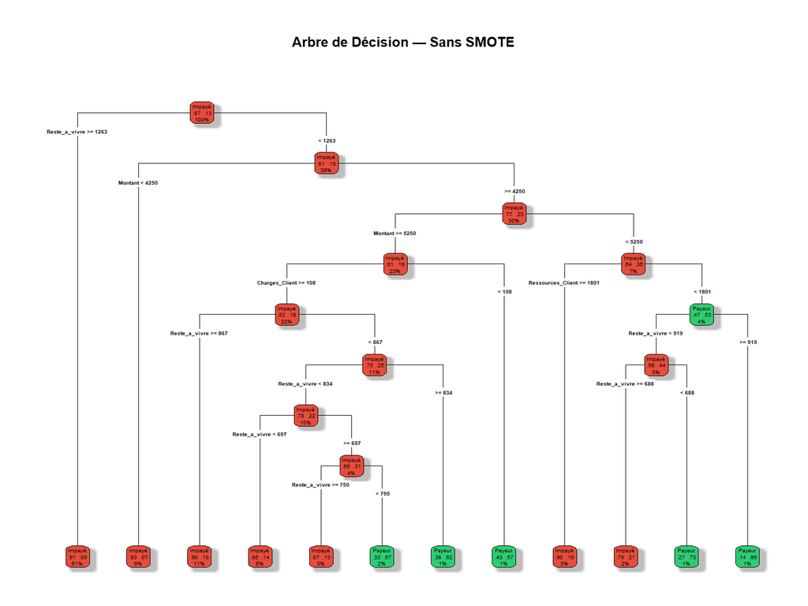

```r
rpart.plot(modele_arbre, type = 4, extra = 104,
           main = "Arbre de Décision — Sans SMOTE",
           box.palette = c("#E74C3C", "#2ECC71"), shadow.col = "gray")
```

```r
prob_arbre  <- predict(modele_arbre, test_set, type = "prob")[, "Payeur"]
pred_arbre  <- factor(ifelse(prob_arbre >= 0.5, "Payeur", "Impayé"),
                      levels = c("Payeur", "Impayé"))
cm_arbre    <- table(Prédit = pred_arbre, Réel = true_f)
print(cm_arbre)
```

```
##         Réel
## Prédit  Payeur Impayé
##   Payeur      4     16
##   Impayé     42    278
```

```r
metr_arbre  <- get_metrics(cm_arbre, "Arbre — Sans SMOTE")
```

### 10.2.2 Avec SMOTE

```r
modele_arbre_smote <- rpart(Payeur ~ . - Mensualite, data = train_smote,
                             method = "class",
                             control = rpart.control(cp = 0.01))
```

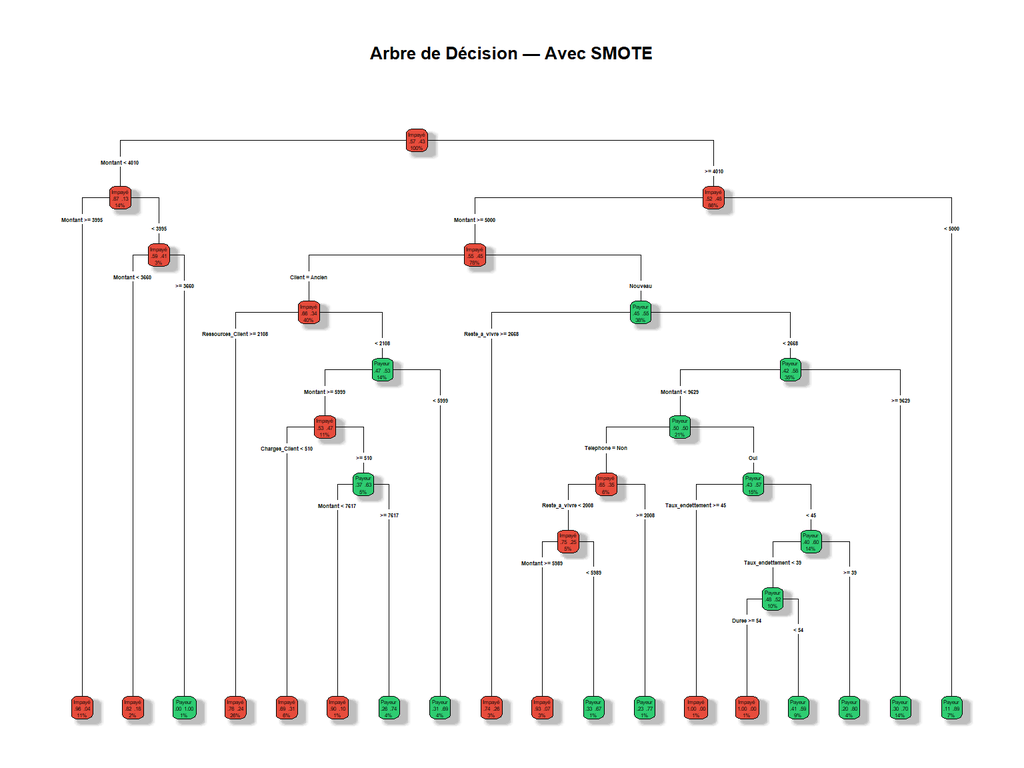

```r
rpart.plot(modele_arbre_smote, type = 4, extra = 104,
           main = "Arbre de Décision — Avec SMOTE",
           box.palette = c("#E74C3C", "#2ECC71"), shadow.col = "gray")
```

```r
prob_arbre_smote <- predict(modele_arbre_smote, test_set, type = "prob")[, "Payeur"]
pred_arbre_smote <- factor(ifelse(prob_arbre_smote >= 0.5, "Payeur", "Impayé"),
                           levels = c("Payeur", "Impayé"))
cm_arbre_smote   <- table(Prédit = pred_arbre_smote, Réel = true_f)
print(cm_arbre_smote)
```

```
##         Réel
## Prédit  Payeur Impayé
##   Payeur     18     82
##   Impayé     28    212
```

```r
metr_arbre_smote <- get_metrics(cm_arbre_smote, "Arbre — Avec SMOTE")
```

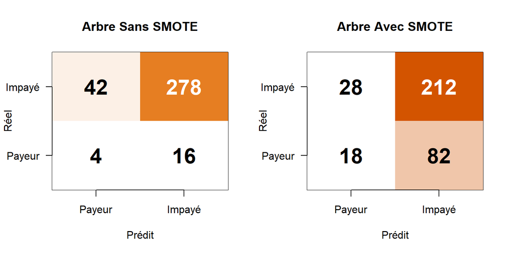

```r
par(mfrow = c(1, 2))
plot_cm(cm_arbre,       "Arbre Sans SMOTE", "#E67E22")
plot_cm(cm_arbre_smote, "Arbre Avec SMOTE", "#D35400")
```

```r
par(mfrow = c(1, 1))
```

## 10.3 Modèle 3 — Forêt Aléatoire

### 10.3.1 Sans SMOTE

```r
set.seed(42)
modele_rf <- randomForest(Payeur ~ . - Mensualite, data = train_set,
                          ntree = 200, importance = TRUE)
print(modele_rf)
```

```
##
## Call:
##  randomForest(formula = Payeur ~ . - Mensualite, data = train_set,      ntree = 200, importance = TRUE)
##                Type of random forest: classification
##                      Number of trees: 200
## No. of variables tried at each split: 3
##
##         OOB estimate of  error rate: 13.35%
## Confusion matrix:
##        Impayé Payeur class.error
## Impayé    687      2 0.002902758
## Payeur    104      1 0.990476190
```

### 10.3.2 Importance des variables

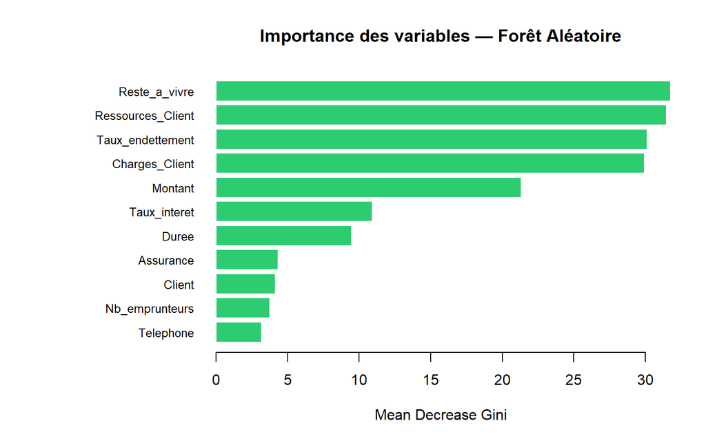

```r
imp <- importance(modele_rf)
imp_df <- imp[order(imp[, "MeanDecreaseGini"], decreasing = FALSE), ]

par(mar = c(5, 12, 4, 2))
barplot(imp_df[, "MeanDecreaseGini"],
        names.arg = rownames(imp_df),
        horiz = TRUE, las = 1,
        col = "#2ECC71", border = "white",
        main = "Importance des variables — Forêt Aléatoire",
        xlab = "Mean Decrease Gini", cex.names = 0.8)
```

```r
par(mar = c(5, 4, 4, 2))
```

```r
prob_rf  <- predict(modele_rf, test_set, type = "prob")[, "Payeur"]
pred_rf  <- factor(ifelse(prob_rf >= 0.5, "Payeur", "Impayé"),
                   levels = c("Payeur", "Impayé"))
cm_rf    <- table(Prédit = pred_rf, Réel = true_f)
print(cm_rf)
```

```
##         Réel
## Prédit  Payeur Impayé
##   Payeur      2      2
##   Impayé     44    292
```

```r
metr_rf  <- get_metrics(cm_rf, "RF — Sans SMOTE")
```

### 10.3.3 Avec SMOTE

```r
set.seed(42)
modele_rf_smote <- randomForest(Payeur ~ . - Mensualite, data = train_smote,
                                ntree = 200, importance = TRUE)

prob_rf_smote  <- predict(modele_rf_smote, test_set, type = "prob")[, "Payeur"]
pred_rf_smote  <- factor(ifelse(prob_rf_smote >= 0.5, "Payeur", "Impayé"),
                         levels = c("Payeur", "Impayé"))
cm_rf_smote    <- table(Prédit = pred_rf_smote, Réel = true_f)
print(cm_rf_smote)
```

```
##         Réel
## Prédit  Payeur Impayé
##   Payeur      9     29
##   Impayé     37    265
```

```r
metr_rf_smote  <- get_metrics(cm_rf_smote, "RF — Avec SMOTE")
```

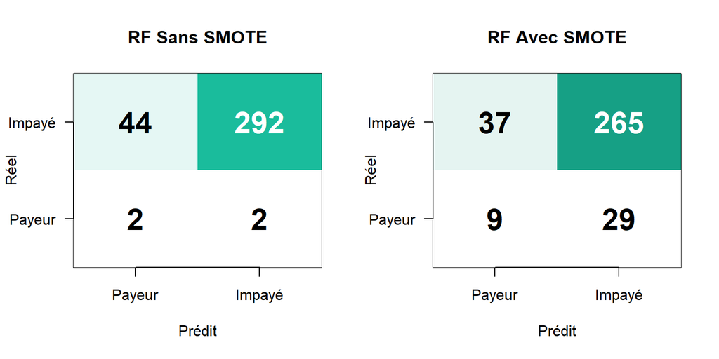

```r
par(mfrow = c(1, 2))
plot_cm(cm_rf,       "RF Sans SMOTE", "#1ABC9C")
plot_cm(cm_rf_smote, "RF Avec SMOTE", "#16A085")
```

```r
par(mfrow = c(1, 1))
```

# 11 Courbes ROC et AUC

## 11.1 Calcul des AUC

```r
roc_lr          <- roc(true_label, prob_lr,          quiet = TRUE)
roc_lr_smote    <- roc(true_label, prob_lr_smote,    quiet = TRUE)
roc_arbre       <- roc(true_label, prob_arbre,       quiet = TRUE)
roc_arbre_smote <- roc(true_label, prob_arbre_smote, quiet = TRUE)
roc_rf          <- roc(true_label, prob_rf,          quiet = TRUE)
roc_rf_smote    <- roc(true_label, prob_rf_smote,    quiet = TRUE)

cat("AUC Régression Logistique Sans SMOTE :", round(auc(roc_lr),          4), "\n")
```

```
## AUC Régression Logistique Sans SMOTE : 0.6367
```

```r
cat("AUC Régression Logistique Avec SMOTE :", round(auc(roc_lr_smote),    4), "\n")
```

```
## AUC Régression Logistique Avec SMOTE : 0.6248
```

```r
cat("AUC Arbre de Décision     Sans SMOTE :", round(auc(roc_arbre),       4), "\n")
```

```
## AUC Arbre de Décision     Sans SMOTE : 0.4816
```

```r
cat("AUC Arbre de Décision     Avec SMOTE :", round(auc(roc_arbre_smote), 4), "\n")
```

```
## AUC Arbre de Décision     Avec SMOTE : 0.4841
```

```r
cat("AUC Forêt Aléatoire       Sans SMOTE :", round(auc(roc_rf),          4), "\n")
```

```
## AUC Forêt Aléatoire       Sans SMOTE : 0.6037
```

```r
cat("AUC Forêt Aléatoire       Avec SMOTE :", round(auc(roc_rf_smote),    4), "\n")
```

```
## AUC Forêt Aléatoire       Avec SMOTE : 0.5669
```

## 11.2 Courbes ROC — comparaison complète

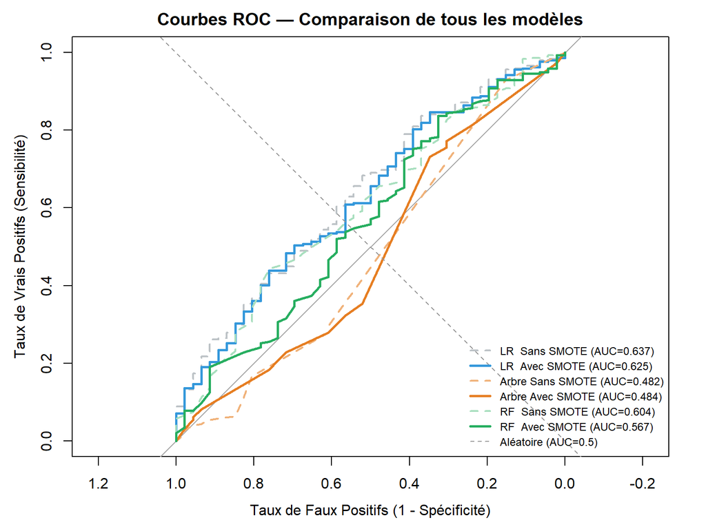

```r
plot(roc_lr,          col = "#BDC3C7", lwd = 2, lty = 2,
     main = "Courbes ROC — Comparaison de tous les modèles",
     xlab = "Taux de Faux Positifs (1 - Spécificité)",
     ylab = "Taux de Vrais Positifs (Sensibilité)")
plot(roc_lr_smote,    col = "#3498DB", lwd = 2.5, add = TRUE)
plot(roc_arbre,       col = "#F0B27A", lwd = 2, lty = 2, add = TRUE)
plot(roc_arbre_smote, col = "#E67E22", lwd = 2.5, add = TRUE)
plot(roc_rf,          col = "#A9DFBF", lwd = 2, lty = 2, add = TRUE)
plot(roc_rf_smote,    col = "#27AE60", lwd = 2.5, add = TRUE)
abline(a = 0, b = 1, col = "gray60", lty = 2, lwd = 1)

legend("bottomright", bty = "n", cex = 0.75,
       legend = c(
         paste0("LR  Sans SMOTE (AUC=", round(auc(roc_lr),          3), ")"),
         paste0("LR  Avec SMOTE (AUC=", round(auc(roc_lr_smote),    3), ")"),
         paste0("Arbre Sans SMOTE (AUC=", round(auc(roc_arbre),     3), ")"),
         paste0("Arbre Avec SMOTE (AUC=", round(auc(roc_arbre_smote),3),")"),
         paste0("RF  Sans SMOTE (AUC=", round(auc(roc_rf),          3), ")"),
         paste0("RF  Avec SMOTE (AUC=", round(auc(roc_rf_smote),    3), ")"),
         "Aléatoire (AUC=0.5)"
       ),
       col = c("#BDC3C7","#3498DB","#F0B27A","#E67E22","#A9DFBF","#27AE60","gray60"),
       lwd = c(2,2.5,2,2.5,2,2.5,1),
       lty = c(2,1,2,1,2,1,2))
```

## 11.3 Seuil Optimal — Indice de Youden

Le seuil de 0.5 n’est pas toujours optimal. L’indice de Youden maximise **Sensibilité + Spécificité - 1**.

```r
# Seuil optimal pour le meilleur modèle (RF avec SMOTE)
coords_rf <- coords(roc_rf_smote, "best", ret = c("threshold","sensitivity","specificity"),
                    best.method = "youden")

# Extraire les valeurs correctement
seuil_opt <- as.numeric(coords_rf["threshold"])
sensib_opt <- as.numeric(coords_rf["sensitivity"])
specif_opt <- as.numeric(coords_rf["specificity"])

cat("=== Seuil Optimal — RF avec SMOTE (Youden) ===\n")
```

```
## === Seuil Optimal — RF avec SMOTE (Youden) ===
```

```r
cat("Seuil       :", round(seuil_opt,        4), "\n")
```

```
## Seuil       : 0.3975
```

```r
cat("Sensibilité :", round(sensib_opt * 100,  2), "%\n")
```

```
## Sensibilité : 83.67 %
```

```r
cat("Spécificité :", round(specif_opt * 100,  2), "%\n")
```

```
## Spécificité : 32.61 %
```

[figure not shown]

```r
plot(roc_rf_smote, col = "#27AE60", lwd = 2.5,
     main = "Courbe ROC — RF Avec SMOTE + Seuil de Youden",
     xlab = "Taux de Faux Positifs (1 - Spécificité)",
     ylab = "Taux de Vrais Positifs (Sensibilité)")
abline(a = 0, b = 1, col = "gray60", lty = 2)

# Point optimal sur la courbe ROC
points(1 - specif_opt, sensib_opt,
       pch = 16, col = "#E74C3C", cex = 2)

text(1 - specif_opt + 0.05, sensib_opt - 0.04,
     labels = paste0("Seuil optimal\n= ", round(seuil_opt, 3)),
     col = "#E74C3C", cex = 0.85)

legend("bottomright",
       legend = c(paste0("RF Avec SMOTE (AUC=", round(auc(roc_rf_smote), 3), ")"),
                  "Seuil Youden optimal"),
       col = c("#27AE60", "#E74C3C"),
       lwd = c(2.5, NA), pch = c(NA, 16), bty = "n")
```

# 12 Optimisation dup_size (1 à 20)

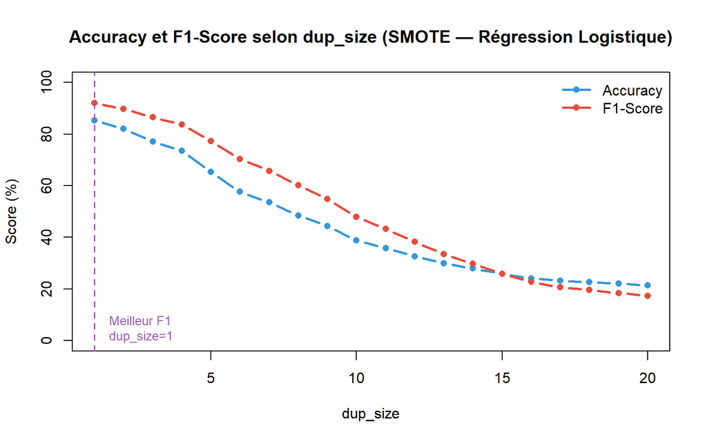

```r
resultats_dup <- data.frame(dup_size = 1:20, Accuracy = NA, F1_Score = NA)

for (d in 1:20) {
  tryCatch({
    set.seed(42)
    sl <- list()
    for (k in 1:d) {
      copie <- train_payeurs
      copie$Montant           <- copie$Montant           + rnorm(nrow(copie), 0, 100)
      copie$Ressources_Client <- copie$Ressources_Client + rnorm(nrow(copie), 0, 50)
      copie$Charges_Client    <- copie$Charges_Client    + rnorm(nrow(copie), 0, 30)
      copie$Taux_endettement  <- copie$Taux_endettement  + rnorm(nrow(copie), 0, 1)
      copie$Reste_a_vivre     <- copie$Reste_a_vivre     + rnorm(nrow(copie), 0, 50)
      sl[[k]] <- copie
    }
    tr <- rbind(train_set, do.call(rbind, sl))
    m  <- glm(Payeur ~ . - Mensualite, data = tr, family = binomial())
    pr <- predict(m, test_set, type = "response")
    pd <- factor(ifelse(pr >= 0.5, "Payeur", "Impayé"), levels = c("Payeur", "Impayé"))
    cm_d <- table(Prédit = pd, Réel = true_f)
    vp_d <- cm_d["Impayé","Impayé"]; fp_d <- cm_d["Impayé","Payeur"]
    fn_d <- cm_d["Payeur","Impayé"]
    p_d  <- round(vp_d/(vp_d+fp_d)*100,2)
    r_d  <- round(vp_d/(vp_d+fn_d)*100,2)
    resultats_dup$Accuracy[d] <- round(sum(diag(cm_d))/sum(cm_d)*100,2)
    resultats_dup$F1_Score[d] <- round(2*p_d*r_d/(p_d+r_d),2)
  }, error = function(e) NULL)
}

best_dup <- resultats_dup$dup_size[which.max(resultats_dup$F1_Score)]

plot(resultats_dup$dup_size, resultats_dup$Accuracy,
     type = "b", col = "#3498DB", lwd = 2.5, pch = 16,
     ylim = c(0, 100), xlab = "dup_size", ylab = "Score (%)",
     main = "Accuracy et F1-Score selon dup_size (SMOTE — Régression Logistique)")
lines(resultats_dup$dup_size, resultats_dup$F1_Score,
      type = "b", col = "#E74C3C", lwd = 2.5, pch = 16)
abline(v = best_dup, col = "#9B59B6", lty = 2, lwd = 1.5)
text(best_dup + 0.5, 5, paste0("Meilleur F1\ndup_size=", best_dup),
     col = "#9B59B6", cex = 0.85, adj = 0)
legend("topright", legend = c("Accuracy", "F1-Score"),
       col = c("#3498DB","#E74C3C"), lwd = 2.5, pch = 16, bty = "n")
```

```r
cat("Meilleur dup_size :", best_dup, "\n")
```

```
## Meilleur dup_size : 1
```

# 13 Tableau Comparatif Final

```r
recap <- rbind(metr_lr, metr_lr_smote,
               metr_arbre, metr_arbre_smote,
               metr_rf, metr_rf_smote)
rownames(recap) <- NULL
print(recap)
```

```
##               Modèle Accuracy Précision Rappel F1_Score
## 1    LR — Sans SMOTE    86.47     86.47 100.00    92.74
## 2    LR — Avec SMOTE    73.53     89.23  78.91    83.75
## 3 Arbre — Sans SMOTE    82.94     86.88  94.56    90.56
## 4 Arbre — Avec SMOTE    67.65     88.33  72.11    79.40
## 5    RF — Sans SMOTE    86.47     86.90  99.32    92.70
## 6    RF — Avec SMOTE    80.59     87.75  90.14    88.93
```

## 13.1 Graphique comparatif — Rappel et F1-Score

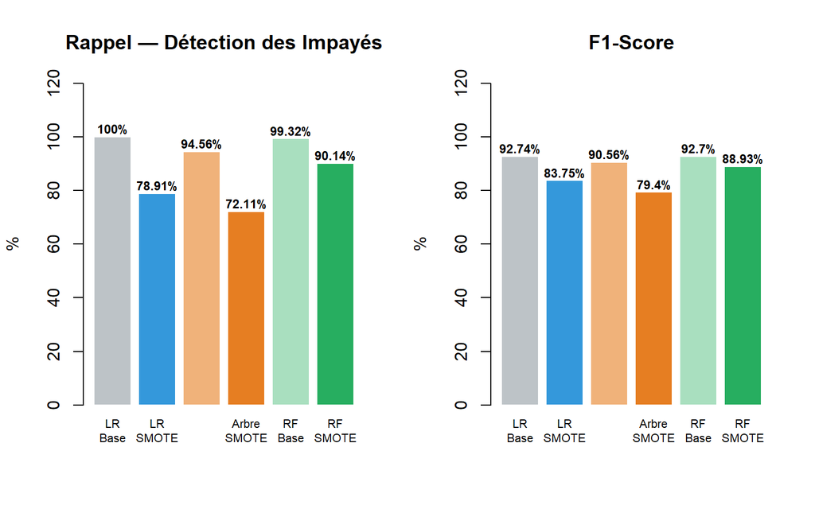

```r
couleurs_recap <- c("#BDC3C7","#3498DB","#F0B27A","#E67E22","#A9DFBF","#27AE60")

par(mfrow = c(1, 2))

# Rappel
bp1 <- barplot(recap$Rappel,
               names.arg = c("LR\nBase","LR\nSMOTE","Arbre\nBase","Arbre\nSMOTE","RF\nBase","RF\nSMOTE"),
               col = couleurs_recap, border = "white",
               main = "Rappel — Détection des Impayés",
               ylab = "%", ylim = c(0, 120), cex.names = 0.7)
text(bp1, recap$Rappel + 3, paste0(recap$Rappel, "%"), font = 2, cex = 0.75)

# F1-Score
bp2 <- barplot(recap$F1_Score,
               names.arg = c("LR\nBase","LR\nSMOTE","Arbre\nBase","Arbre\nSMOTE","RF\nBase","RF\nSMOTE"),
               col = couleurs_recap, border = "white",
               main = "F1-Score",
               ylab = "%", ylim = c(0, 120), cex.names = 0.7)
text(bp2, recap$F1_Score + 3, paste0(recap$F1_Score, "%"), font = 2, cex = 0.75)
```

```r
par(mfrow = c(1, 1))
```

## 13.2 Graphique comparatif — AUC

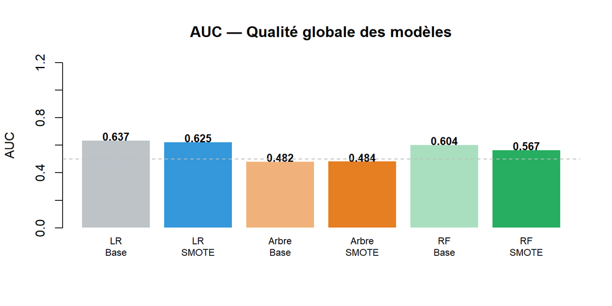

```r
auc_vals <- c(round(auc(roc_lr),3), round(auc(roc_lr_smote),3),
              round(auc(roc_arbre),3), round(auc(roc_arbre_smote),3),
              round(auc(roc_rf),3), round(auc(roc_rf_smote),3))

bp3 <- barplot(auc_vals,
               names.arg = c("LR\nBase","LR\nSMOTE","Arbre\nBase","Arbre\nSMOTE","RF\nBase","RF\nSMOTE"),
               col = couleurs_recap, border = "white",
               main = "AUC — Qualité globale des modèles",
               ylab = "AUC", ylim = c(0, 1.2), cex.names = 0.75)
text(bp3, auc_vals + 0.03, auc_vals, font = 2, cex = 0.85)
abline(h = 0.5, col = "gray", lty = 2)
```

# 14 Conclusion

## 14.1 Synthèse des résultats

```
##               Modèle Accuracy Précision Rappel F1_Score
## 1    LR — Sans SMOTE    86.47     86.47 100.00    92.74
## 2    LR — Avec SMOTE    73.53     89.23  78.91    83.75
## 3 Arbre — Sans SMOTE    82.94     86.88  94.56    90.56
## 4 Arbre — Avec SMOTE    67.65     88.33  72.11    79.40
## 5    RF — Sans SMOTE    86.47     86.90  99.32    92.70
## 6    RF — Avec SMOTE    80.59     87.75  90.14    88.93
```

## 14.2 Interprétation finale

Le jeu de données présentait un **fort déséquilibre** (86.7% Impayés / 13.3% Payeurs). Voici les enseignements principaux :

**Contexte métier**

Dans le risque de crédit, le **rappel est la métrique prioritaire** : rater un vrai impayé coûte bien plus cher qu’une fausse alarme. Le seuil optimal calculé par l’indice de Youden est préférable au seuil arbitraire de 0.5.

[output not shown]